# Latihan 1

Putra Ramadhana

## Packages

```r
library(lmtest)   # uji Durbin-Watson
library(orcutt)   # metode Cochrane-Orcutt
```

1. **Plot sisaan** (sisaan vs urutan waktu / periode)
2. **Uji Durbin-Watson**

Jika ditemukan autokorelasi, dilakukan penanganan dengan dua metode:

- **Metode Cochrane-Orcutt** — mengestimasi $\rho$ (koefisien autokorelasi orde satu) secara iteratif menggunakan `orcutt::cochrane.orcutt()`, lalu mentransformasi data dengan $\rho$ tersebut.
- **Metode Hildreth-Lu** — mencari nilai $\rho$ optimum melalui pencarian grid (*grid search*) yang meminimumkan Jumlah Kuadrat Sisaan (JKS/SSE) dari model yang telah ditransformasi:

$$Y_t-\rho Y_{t-1}=\beta_0(1-\rho)+\beta_1(X_t-\rho X_{t-1})+\varepsilon_t$$

```r
# Fungsi Hildreth-Lu (transformasi data dengan rho, lalu OLS)
hildreth.lu <- function(y, x, rho){
  t <- 2:length(y)
  y <- y[t] - rho * y[t-1]
  x <- x[t] - rho * x[t-1]
  return(lm(y ~ x))
}
```

# Data 1: Market Share vs Price

## Impor Data

```r
Period <- 1:20
Market_Share <- c(3.63, 4.20, 3.33, 4.54, 2.89, 4.87, 4.90, 5.29, 6.18, 7.20,
                   7.25, 6.09, 6.80, 8.65, 8.43, 8.29, 7.18, 7.90, 8.45, 8.23)
Price <- c(0.97, 0.95, 0.99, 0.91, 0.98, 0.90, 0.89, 0.86, 0.85, 0.82,
           0.79, 0.83, 0.81, 0.77, 0.76, 0.80, 0.83, 0.79, 0.76, 0.78)
d1 <- data.frame(Period, Market_Share, Price)
d1
```

```
##    Period Market_Share Price
## 1       1         3.63  0.97
## 2       2         4.20  0.95
## 3       3         3.33  0.99
## 4       4         4.54  0.91
## 5       5         2.89  0.98
## 6       6         4.87  0.90
## 7       7         4.90  0.89
## 8       8         5.29  0.86
## 9       9         6.18  0.85
## 10     10         7.20  0.82
## 11     11         7.25  0.79
## 12     12         6.09  0.83
## 13     13         6.80  0.81
## 14     14         8.65  0.77
## 15     15         8.43  0.76
## 16     16         8.29  0.80
## 17     17         7.18  0.83
## 18     18         7.90  0.79
## 19     19         8.45  0.76
## 20     20         8.23  0.78
```

## Regresi OLS (Cross Section)

```r
model1 <- lm(Market_Share ~ Price, data = d1)
summary(model1)
```

```
##
## Call:
## lm(formula = Market_Share ~ Price, data = d1)
##
## Residuals:
##      Min       1Q   Median       3Q      Max
## -0.73068 -0.29764 -0.00966  0.30224  0.81193
##
## Coefficients:
##             Estimate Std. Error t value Pr(>|t|)
## (Intercept)   26.910      1.110   24.25 3.39e-15 ***
## Price        -24.290      1.298  -18.72 3.02e-13 ***
## ---
## Signif. codes:  0 '***' 0.001 '**' 0.01 '*' 0.05 '.' 0.1 ' ' 1
##
## Residual standard error: 0.4287 on 18 degrees of freedom
## Multiple R-squared:  0.9511, Adjusted R-squared:  0.9484
## F-statistic: 350.3 on 1 and 18 DF,  p-value: 3.019e-13
```

Model awal yang terbentuk:

$$\hat{Market Share} = 26.910 - 24.290\,Price$$

Baik intersep maupun koefisien *Price* signifikan ($p<0.001$), dan model menjelaskan 95.1% keragaman *Market Share* ($R^2=0.9511$).

## Deteksi Autokorelasi

### Plot Sisaan

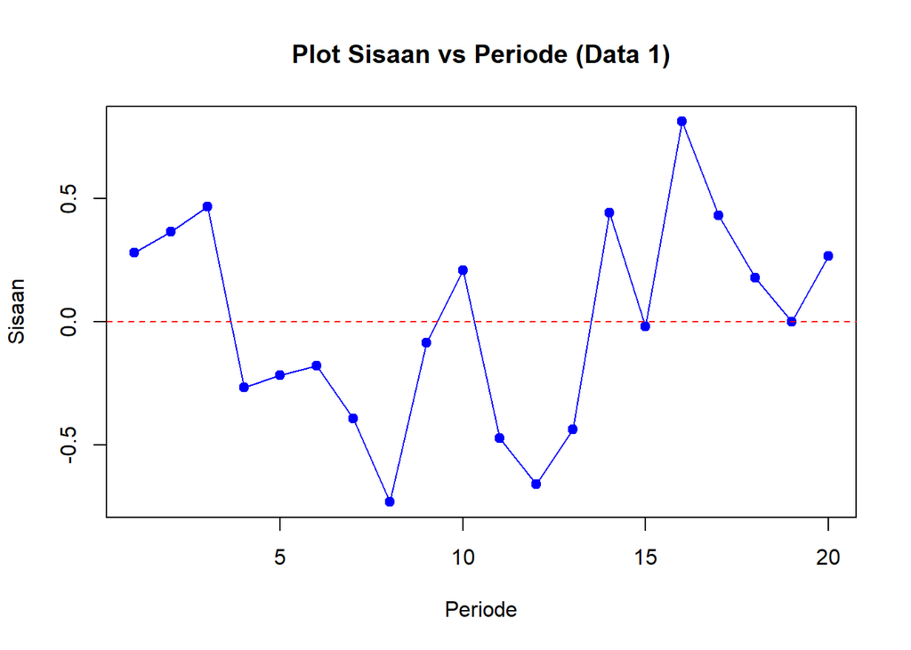

```r
plot(d1$Period, residuals(model1), type = "o", pch = 19, col = "blue",
     xlab = "Periode", ylab = "Sisaan", main = "Plot Sisaan vs Periode (Data 1)")
abline(h = 0, col = "red", lty = 2)
```

Plot sisaan menunjukkan pola yang tidak acak — sisaan cenderung bergerombol (beberapa periode berurutan bernilai positif, lalu beberapa periode berurutan bernilai negatif). Pola musiman/menggelombang ini mengindikasikan adanya **autokorelasi positif**.

### Uji Durbin-Watson

```r
dwtest(model1)
```

```
##
##  Durbin-Watson test
##
## data:  model1
## DW = 1.1358, p-value = 0.009813
## alternative hypothesis: true autocorrelation is greater than 0
```

Nilai $DW = 1.136$ dengan $p$*-value* $= 0.0098 < 0.05$, sehingga tolak $H_0$. **Kesimpulan: terdapat autokorelasi (positif) pada sisaan model**, sehingga perlu dilakukan penanganan.

## Penanganan Autokorelasi

### Metode 1: Cochrane-Orcutt

```r
model1.co <- cochrane.orcutt(model1)
model1.co
```

```
## Cochrane-orcutt estimation for first order autocorrelation
##
## Call:
## lm(formula = Market_Share ~ Price, data = d1)
##
##  number of interaction: 8
##  rho 0.425232
##
## Durbin-Watson statistic
## (original):    1.13582 , p-value: 9.813e-03
## (transformed): 1.95804 , p-value: 4.151e-01
##
##  coefficients:
## (Intercept)       Price
##    26.72209   -24.08413
```

Metode Cochrane-Orcutt mengestimasi $\rho = 0.4252$. Setelah transformasi, nilai DW naik dari 1.136 menjadi **1.958** dengan $p$*-value* $= 0.415 > 0.05$, artinya autokorelasi sudah **tertangani**. Model akhir:

$$\hat{Market Share} = 26.722 - 24.084\,Price$$

### Metode 2: Hildreth-Lu

Dilakukan pencarian $\rho$ pada rentang 0.1 - 0.9 yang meminimumkan SSE.

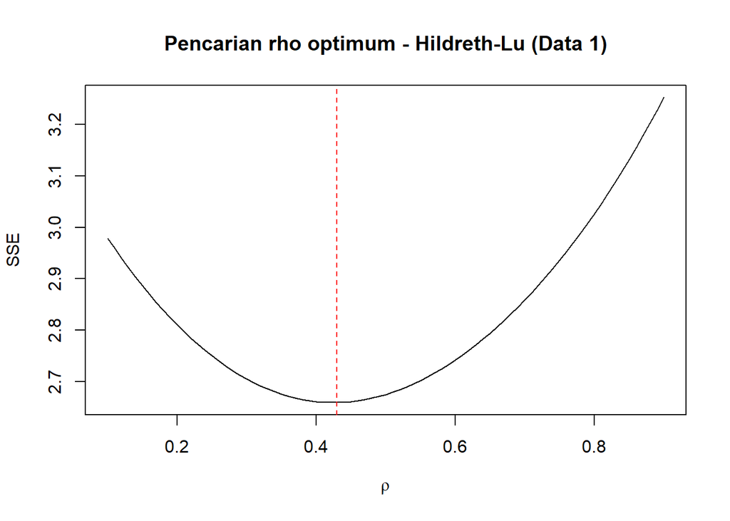

```r
rho <- seq(0.1, 0.9, 0.01)
SSE <- sapply(rho, function(r) sum(residuals(hildreth.lu(d1$Market_Share, d1$Price, r))^2))

tab1 <- data.frame(rho, SSE)
plot(tab1$rho, tab1$SSE, type = "l", xlab = expression(rho), ylab = "SSE",
     main = "Pencarian rho optimum - Hildreth-Lu (Data 1)")
rho1.opt <- tab1$rho[which.min(tab1$SSE)]
abline(v = rho1.opt, col = "red", lty = 2)
```

```r
rho1.opt
```

```
## [1] 0.43
```

$\rho$ optimum yang meminimumkan SSE adalah **0.43**, sangat dekat dengan hasil Cochrane-Orcutt (0.4252).

```r
model1.hl <- hildreth.lu(d1$Market_Share, d1$Price, rho1.opt)
summary(model1.hl)
```

```
##
## Call:
## lm(formula = y ~ x)
##
## Residuals:
##     Min      1Q  Median      3Q     Max
## -0.5532 -0.2512 -0.0552  0.2493  0.8302
##
## Coefficients:
##             Estimate Std. Error t value Pr(>|t|)
## (Intercept)  15.2246     0.9349   16.29 8.35e-12 ***
## x           -24.0694     1.9474  -12.36 6.40e-10 ***
## ---
## Signif. codes:  0 '***' 0.001 '**' 0.01 '*' 0.05 '.' 0.1 ' ' 1
##
## Residual standard error: 0.3955 on 17 degrees of freedom
## Multiple R-squared:  0.8999, Adjusted R-squared:  0.894
## F-statistic: 152.8 on 1 and 17 DF,  p-value: 6.396e-10
```

```r
# intersep asli (back-transform karena intersep hasil transformasi = intersep_asli*(1-rho))
intercept1.hl <- coef(model1.hl)[1] / (1 - rho1.opt)
cat("Intersep model asli:", intercept1.hl, "\n")
```

```
## Intersep model asli: 26.70977
```

```r
cat("Slope Price:", coef(model1.hl)[2], "\n")
```

```
## Slope Price: -24.06941
```

```r
dwtest(model1.hl)
```

```
##
##  Durbin-Watson test
##
## data:  model1.hl
## DW = 1.9656, p-value = 0.4228
## alternative hypothesis: true autocorrelation is greater than 0
```

Setelah transformasi Hildreth-Lu, DW naik menjadi **1.966** ($p=0.423>0.05$), autokorelasi juga sudah tertangani, dengan model akhir:

$$\hat{Market Share} = 26.71 - 24.069\,Price$$

## Kesimpulan Data 1

Kedua metode (Cochrane-Orcutt dan Hildreth-Lu) memberikan estimasi $\rho$ yang hampir identik (0.4252 vs 0.43) serta koefisien model akhir yang sangat mirip, dan **keduanya berhasil menghilangkan autokorelasi** (DW mendekati 2 dan $p$*-value* $>0.05$ pada kedua kasus). Model akhir yang direkomendasikan:

$$\hat{Market Share} \approx 26.7 - 24.1\,Price$$

Interpretasinya: setiap kenaikan harga (*Price*) sebesar 1 satuan berkaitan dengan penurunan pangsa pasar sekitar 24.1 poin, setelah mengoreksi autokorelasi sisaan akibat sifat data deret waktu.